# Manuscript

2017-07-31

# Introduction

### Evaluating MLL with harvest occurring below MLL

Output controls like bag and length limits are a common tool used to prevent overfishing and manage size structure of inland freshwater fish populations.

- Meet varying objectives
  - Harvest opportunities: subsistence, deep hooking, so on
  - Simplicity
  - Size structure - minimize harvest of big fish
- Reduced bag limits (25 to 10) increased mean size of panfish on average 20.3 mm {Rypel, 2015 #5166}
- a 200-mm minimum length limit did minimally increase size structure at current levels of exploitation across all 18 bluegill populations, the populations with the lowest natural mortality and fastest growth provided the highest increase in size structure with the lowest reduction in yield and number harvested {Paukert, 2002 #5167}
- MLL have limited effect in catch and release fishery - Miranda et al in review
- YPR results suggest a length limit could improve both yield and average weight for crappie fisheries only if growth is rapid and natural mortality is low {Allen, 1995 #4836}

### Crappie Management using length limits [keep?]

Due to increased fishing pressure and angler success minimum length limits (MLL) have become a necessary management tool to prevent overharvest and to meet angler demands for larger fish in the system (Boxrucker 2002; Hale et al. 1999).

- The use of harvest restrictions can help improve harvest only if growth is fast and natural mortality is low.
- Conversely, crappie population yield will potentially decrease when growth is slower and natural mortality increases (Miranda and Allen 1995).
- Black crappie *Pomoxis nigromaculatus* and white crappie *Pomoxis annularis* are popular and economically important North American sport fish.
- Many anglers often cite crappie as first or second in angler preference (McDonough and Buchanan 1991; Mitzner 1991).
- Deep hooking, subsistence, harvest opportunity

### Systems with over under regulations (not unique to lake washington)

Harvest of fish below a minimum length limit is allowed in fisheries to meet varying management objectives.

- Objectives satisfied by harvest under MLL?
  - Harvest opportunities: subsistence, angler satisfaction
  - Deep hooking, unlikely to survive
  - Limit harvest of larger trophy sized fish
  - Limit harvest of large female, reproductively valuable
- Florida 2016- Largemouth bass 5 daily, only 1 over 16 inches (http://myfwc.com/fishing/freshwater/black-bass/bass-regulations/changes/)
  - Done to simplify regulations, no zones with different length and bag limits
  - Simplicity among waters
  - it is ok to harvest smaller fish, especially bass
- Bass (Largemouth, smallmouth, spotted in Virginia
  - https://www.dgif.virginia.gov/wp-content/uploads/creel-and-length-limits.pdf
  - Smith Mt. Lake and its tributaries below Niagara Dam, only 2 of 5 less than 14 inches
  - Base of Shenandoah Dam, near Town of Shenandoah, downstream to Luray Dam, near Luray No bass 14 to 20 inches, only 1 per day longer than 20 inches
- Minnesota walleye and sauger
  - http://www.dnr.state.mn.us/fishmn/regs.html?topic=inland&section=seaons_and_limits
  - 6 combined, not more than one walleye over 20"
- Idaho - RBT
  - https://idfg.idaho.gov/sites/default/files/seasons-rules-fish-2016-2018.pdf
  - Pend Oreille Lake - RBT limit is 2 only 1 over 20 inches

### Lake Washington and declines, not data evidence, but needed YPR

Harvest of fish under the minimum length limit can result in conflict among angler groups that perceive harvest is causing population and size structure declines.

- Lake Washington is well known for the number of crappie caught, as well as, producing trophy sized fish.
- It is a very popular crappie fishery for recreational, tournament, as well as subsistence anglers.
- Since many local anglers are fishing for subsistence, a unique rule for the system, the “5 under rule”, was put in place.
- This rule allows anglers to keep up to 5 fish under the current MLL of 254 mm a day.
- In 2015, a petition was signed by 595 anglers that called for an increase in the Minimum Length Limit (MLL) and to drop the “5 under rule”.
- Anglers who signed this petition gave the primary reason for wanting a new regulation was that harvest rates and average weights had decreased in recent years with increased fishing pressure.
- MDWFP monitoring data has not shown an obvious decline
- Mississippi Department of Wildlife, Fisheries and Park wanted to evaluate the effects on yield of MLL of 254, 279.4, or 304.8 millimeter

### Objectives and study overview

The objectives of this study were to:

1. develop a yield per recruit model that accounts for harvest occurring below the MLL, and
2. use the model to evaluate a 10, 11, and 12 inch MLL on growth and recruit overfishing of White and Black Crappie (hereafter crappie) in Lake Washington.

# Methods

## Study Area

The study took place on Lake Washington, in Washington County, Mississippi (33.0773N, 91.0466W). Lake Washington is an oxbow lake of the Mississippi River and one of the largest natural lakes in the state (2,023 ha). Lake depth averages 1.8 meters maximum depth is 6.7 m. Lake Washington is well known for its crappie fishing and is a popular fishing destination for Sportfish found in the lake include Largemouth Bass *Micropterus salmoides*, Bluegill *Lepomis macrochirus*, Channel Catfish *Ictalurus punctatus*, Black Crappie *Pomoxis nigromaculatus*, and White Crappie *Pomoxis annularis*. Black and White Crappie (hereafter crappie refers to Black and White Crappie) are often fished for as one species in this system, and in turn, are managed as one species. During this study crappie harvest was regulated with a 254 mm MLL and a daily bag limit of 30 fish of which anglers are allowed to keep 5 fish under the 254 mm MLL.

## Yield Per recruit and spawning potential ratio

Traditionally YPR models only account for yield occurring above the MLL. Since Lake Washington has the unique regulation allowing for harvest of 5 crappie under the MLL, we had to develop a modified model. The new, modified model needs the same information as a traditional Beverton-Holt model: 1) mortality rate, weight-length relationship, length-age relationship, and a sex ratio. By using this new model we were able to evaluate the 3 proposed MLL, 254 mm (current), 279.4 mm, and 304.80; while accounting for various fishing mortalities below the MLL (0, 0.01, 0.05, 0.1, 0.2). By evaluating various fishing mortality below the MLL we were able to evaluate the potential effect of fishing mortality below the MLL, while still evaluating that effect that different length limits would have on yield in the system. This would also allow us to see when, if at all, growth overfishing could occur in the system.

$$\frac{dN}{dt}=-({{N}_{t}}\cdot ({{F}_{t}}+M))$$

$$\frac{dY}{dt}={{F}_{t}}\cdot {{N}_{t}}\cdot {{W}_{t}}$$

${{W}_{t}}=a\cdot {{\left( {{L}_{\infty }}\cdot (1-{{e}^{k\cdot (t-{{t}_{0}})}} \right)}^{b}}$

$F(t)=\left\{ \begin{matrix} {{F}_{below\,mll}}, & {{t}_{h}}\le t<{{t}_{r}} \\ {{F}_{above\,mll}}, & {{t}_{r}}\le t \\ \end{matrix} \right.$ (4)

$\frac{dEggs}{dt}={{N}_{t}}\cdot [Sex\,ratio]\cdot {{P}_{mature,t}}\cdot Fecundit{{y}_{t}}$ ${{P}_{mature}}=\frac{1}{1+{{e}^{(-(t-{{t}_{mat}})/{{\sigma }_{mat}})}}}$ * t=1 to lambda using livermore * R = 1000

## Fish and Fishery Data Collection

Fish sampling was conducted on October 4, 2015 – October 6, 2015. Trap and lead nets were set on October 4 in twelve different locations in Lake Washington. The traps were then checked and reset on October 5, and checked again on October 6. At each net location, water temperature and depth was recorded, as well as any additional comments. Every fish that was caught in a net was identified and total length was recorded to the nearest millimeter (mm). The first 5 crappie caught from each centimeter group were kept and weighed and aged at a later date.

The trap nets are constructed of two 3 foot x 6 foot x 1 inch fiberglass frames, with four 2.5 foot diameter hoops in the fiberglass. Hoops are 2 feet apart. The netting is square knotless treated nylon with 0.5 inch openings. The trap nets are 40 feet in length, 3 feet in depth, and attached to the first frame. The lead nets that we used were constructed with two hoops facing each other, and are connected with a lead that attaches to each hoop net. The net and lead are constructed from 1 inch treated bar mesh. The hoops are constructed of 7 fiberglass hoops, with a diameter of 3.5 feet, which are separated by 2 feet with throats located at the 2nd and 4th hoop. The lead between the two hoops nets is 30 feet in length.

## Mortality and Exploitation

Mortality rates were provided by Mississippi Department of Wildlife, Fisheries, and Parks, N. Aycock, unpublished data. In 2012 MDWFP caught and aged crappie from Lake Washington in order to establish an annual mortality rate. An annual mortality rate of 66% was calculated using a weighted catch curve. A tag return study was done in 2014-2015 in order to establish an annual exploitation rate. The study was done by tagging 400 fish greater than the MLL (>254 mm) and a reward was given out for each returned tags. After taking into account tagging mortality, non-reporting, and tag loss, the annual exploitation rate was found to be 41%. We would use this exploitation rate for our yield per recruit models.

## Length-weight and Age-length Relationship

The first 5 crappie that were caught, from each centimeter bin, were measured for total length and kept to be weighed. This fish were then measured again and weighed before being aged. The data was entered into excel and the parameters for the length-weight relationship were established.

Weights were recorded and otoliths were pulled and taken to Mississippi State University to be aged. Aging was done by counting growth rings on the otolith under a Leica DFC 290 HD microscope. Each otolith was aged by Maddy Ruble and myself. The otoliths were ages independently and then compared. If a disagreement occurred, the otolith was reviewed together until a consensus was reached. In order to establish a growth curve, needed to run Yield per Recruit models, we fit a von Bertalanffy growth function to the size and age of the crappie aged from Lake Washington.

$L\left( t \right)={{L}_{\infty }}(1-{{e}^{k~\cdot (t-{{t}_{0}})~}})$

- Implemented in R with a shiny interface

# Results

## Data Collection

The minimum length of a crappie that we recorded was 100 mm and the maximum length recorded was 364 mm. The range of lengths recorded for Black Crappie was 105 mm – 359 mm with an average of 242.55 mm. White Crappie ranged in length from 100 mm – 364 mm and averaged 227.19 mm. The majority of small fish (around 100 mm) were White Crappie.

## Length-weight and age-length Relationship

The lengths and weights that were recorded from the kept crappie was entered into excel and the used to form a length-weight relationship. Once the date was entered the log10 and regression function of excel was used to find the intercept (a), 5.8E-07, and slope (b), 3.615.

Once the fish were aged and the data was entered into excel a von Bertalanffy growth function was fit to the data. The solver function of Microsoft Excel was to fit the growth function to the data. Length at infinity is 343.97 mm, k is 0.395, and t0 is -1.026. By understanding at what age most fish reach 254 mm we can assess growth overfishing. Most of the Black Crappie reached 254 mm by age 2, while most of the White Crappie seemed to reach the current MLL at ages 1-4.

## Yield per Recruit analysis

# Discussion

Crappyie are an important sportfish in the United States (Maceina and Stimpert 1998). They are often managed for as the same species because anglers rarely differentiate between the two species (Mitzner 1991). For this study we evaluated the two species together because under the current regulations there is no difference in length limits or bag limits for Black and White Crappie.

However, one species is often more abundant than the other in one system (Sammons et al. 2002). Assuming that Catch per Unit Effort in Lake Washington is linearly related to abundance, it can be suggested that there is more Black Crappie than White Crappie in the system. There is data that suggest that there may be a bias for Black Crappie when using trap nets, resulting in more Black Crappie being sampled that white crappie when relying solely on trap style nets for catch data (Sammons et al. 2002). It is also is shown that electrofishing may be more effective in capturing larger fish needed to obtain age and growth data, and that trap nets may be biased to smaller, younger fish (Sammons et al. 2002).

Electrofishing in the spring could be done to add data, and improve the yield per recruit models. In our study, the mean length and weight was greater for Black Crappie than White Crappie.

The mean age of White Crappie captured was also lower than the mean age of Black Crappie captured. This could suggest that trap nets are biased to capturing more Black Crappie, and that some electrofishing may also be needed to sample the larger fish in the system.

Length limits have become increasingly popular ways on managing to meet angler demands of larger fish in the system. In many systems, harvest numbers, not larger sized fish, is of more importance to crappie anglers (Hale et all 1999). Lake Washington may be unique in that some anglers are specially seeking the larger trophy sized fish, yet others are seeking large numbers of fish harvested (N. Aycock, unpublished data). In a study by Hale et al. (1999), a 254 mm length limit was imposed on the Delaware Reservoir to increase size of crappie caught without greatly reducing harvest numbers. The length limit was successful in increasing the mean size of fish caught, but it did dramatically decrease annual yield. However, improvements to fisheries are specific to the study area and are susceptible to fluctuating year class strength (Webb and Ott 1991).

White Crappie are thought to grow faster than Black Crappie due to their piscivorous diet (Ellison 1984). In a 2002 study, Sammons et al. found data that supported this conclusion. They found that by age 4, Black Crappie were on average 30 mm smaller than White Crappie. Variability in size at the same age could affect the age at which one of the species is effected by the MLL. If White Crappie are reaching the MLL before Black Crappie, and are less abundant that Black Crappie in the system, catch rates could be potentially affected.

- Blacks versus whites and justification for combining, CPUE suggests they are a small component of Crappie stock, But there could be some habitat segregation (any papers documenting different growth? Different mortality rates?)
- Effect of increasing MLL ? increased opportunities to harvest 5 under because more fish from 8? 12” versus 8? 10”, Creel indicates 8” over is harvested (N. Aycock Unpublished data)

# Tables

# Figures

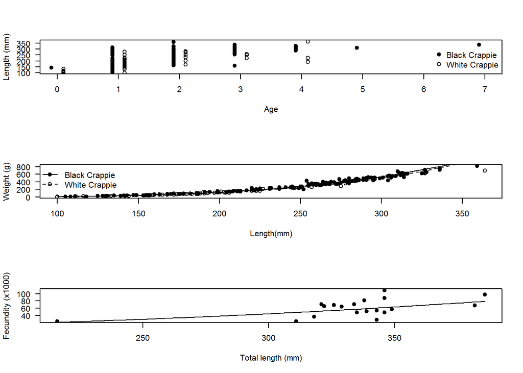

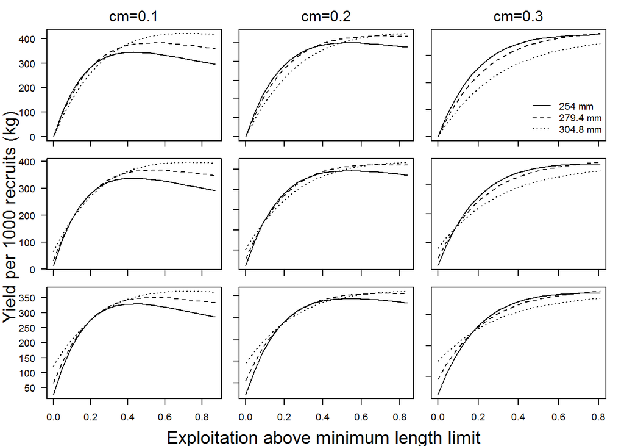

Figure 2. Yield per 1000 recruits (*y*-axis) for varying conditional natural mortality rates and exploitation rates. Top panels represent no fishing mortality below the minimum length limit. The middle and bottom rows represent 0.1 and 0.2 respectively.

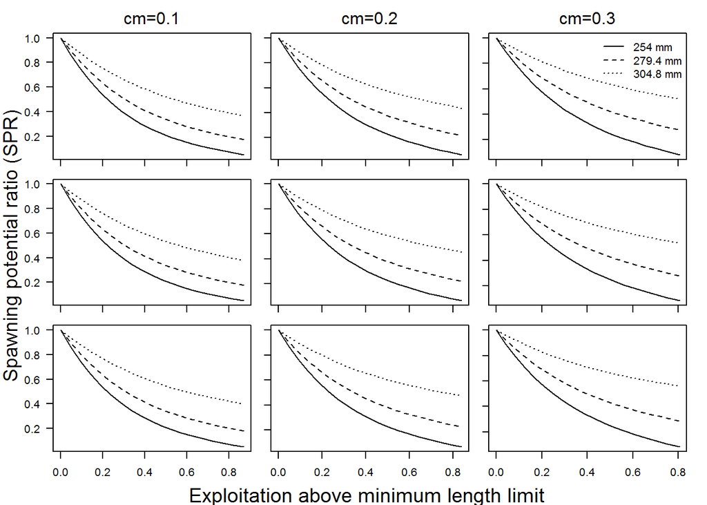